# Background

This dataset is for customers who purchased Treadmill product(s) from a retail store called Cardio Good Fitness.

# Objective

- Come up with a customer profile (characteristics of a customer) for each Treadmill product
- Perform uni-variate and multi-variate analyses
- Generate a set of insights and recommendations that will help the company in targeting new customers

# Key Questions to be Answered

- Are there any differences between customers of each product?
- Is there any relationship patterns that can be observed between the different attributes of customers?

# Dataset

- Product - the model no. of the treadmill
- Age - in no of years, of the customer
- Gender - of the customer
- Education - in no. of years, of the customer
- Marital Status - of the customer
- Usage - Avg. # times the customer wants to use the treadmill every week
- Fitness - Self rated fitness score of the customer (5 - very fit, 1 - very unfit)
- Income - of the customer
- Miles- expected to run

### Import the necessary packages - pandas, numpy, seaborn, matplotlib.pyplot

```python
import pandas as pd
import numpy as np
import matplotlib.pyplot as plt
import seaborn as sns
sns.set_theme(style="darkgrid")
%matplotlib inline
import warnings
warnings.filterwarnings("ignore") #to avoid warnings
from PIL import Image
pd.set_option('display.float_format', lambda x: '%.5f' % x) # To supress numerical display in scientific notations
```

### Read in the dataset

```python
cardiofit = pd.read_csv("CardioGoodFitness.csv")
```

### View the first 10 rows of the dataset

```python
cardiofit.head(10)
```

|  | Product | Age | Gender | Education | MaritalStatus | Usage | Fitness | Income | Miles |
| --- | --- | --- | --- | --- | --- | --- | --- | --- | --- |
| 0 | TM195 | 18 | Male | 14 | Single | 3 | 4 | 29562 | 112 |
| 1 | TM195 | 19 | Male | 15 | Single | 2 | 3 | 31836 | 75 |
| 2 | TM195 | 19 | Female | 14 | Partnered | 4 | 3 | 30699 | 66 |
| 3 | TM195 | 19 | Male | 12 | Single | 3 | 3 | 32973 | 85 |
| 4 | TM195 | 20 | Male | 13 | Partnered | 4 | 2 | 35247 | 47 |
| 5 | TM195 | 20 | Female | 14 | Partnered | 3 | 3 | 32973 | 66 |
| 6 | TM195 | 21 | Female | 14 | Partnered | 3 | 3 | 35247 | 75 |
| 7 | TM195 | 21 | Male | 13 | Single | 3 | 3 | 32973 | 85 |
| 8 | TM195 | 21 | Male | 15 | Single | 5 | 4 | 35247 | 141 |
| 9 | TM195 | 21 | Female | 15 | Partnered | 2 | 3 | 37521 | 85 |

### Observation

- There are Male and Female customers
- And the customers are Single and Partnered

### Check the shape of the dataset

```python
cardiofit.shape
```

```
(180, 9)
```

### Observation

We have 180 observations of 9 columns

```python
cardiofit.columns
```

```
Index(['Product', 'Age', 'Gender', 'Education', 'MaritalStatus', 'Usage',
       'Fitness', 'Income', 'Miles'],
      dtype='object')
```

### Observation

There are 9 variables in this data set: 'Product', 'Age', 'Gender', 'Education', 'MaritalStatus', 'Usage', 'Fitness', 'Income', 'Miles'

### Check the datatype of the variables to make sure that the data is read in properly

```python
cardiofit.dtypes
```

```
Product          object
Age               int64
Gender           object
Education         int64
MaritalStatus    object
Usage             int64
Fitness           int64
Income            int64
Miles             int64
dtype: object
```

### Observations

1. Product, Gender and MaritalStatus are Categorical data type (object/string)
2. All the other variables are Numerical data type (int64)

### Find out the unique values of Treadmill Product

```python
print(cardiofit.Product.unique())
```

```
['TM195' 'TM498' 'TM798']
```

### Observation

- There are totally 3 Treadmill products

### Generates descriptive statistics that summarize the central tendency, dispersion and shape of a dataset’s distribution, excluding NaN/Missing values

```python
cardiofit.describe()
```

|  | Age | Education | Usage | Fitness | Income | Miles |
| --- | --- | --- | --- | --- | --- | --- |
| count | 180.00000 | 180.00000 | 180.00000 | 180.00000 | 180.00000 | 180.00000 |
| mean | 28.78889 | 15.57222 | 3.45556 | 3.31111 | 53719.57778 | 103.19444 |
| std | 6.94350 | 1.61705 | 1.08480 | 0.95887 | 16506.68423 | 51.86360 |
| min | 18.00000 | 12.00000 | 2.00000 | 1.00000 | 29562.00000 | 21.00000 |
| 25% | 24.00000 | 14.00000 | 3.00000 | 3.00000 | 44058.75000 | 66.00000 |
| 50% | 26.00000 | 16.00000 | 3.00000 | 3.00000 | 50596.50000 | 94.00000 |
| 75% | 33.00000 | 16.00000 | 4.00000 | 4.00000 | 58668.00000 | 114.75000 |
| max | 50.00000 | 21.00000 | 7.00000 | 5.00000 | 104581.00000 | 360.00000 |

### Important Observations

- The maximum age of the customer purchasing the Treadmill products is 50 years old and age of 50% of the customers is 26 years old.
- 50% of customers purchasing the Treadmill products gave self rated fitness on scale of 3.
- 50% of customers have 16 years of education, which means they have at least college degree.
- The median income of the customers is 50K USD per annum.
- 50% of customers expect to run 94 miles per week.
- 50% of customers expected usage of Treadmill is 3 times per week

### Other Observations

```python
cardiofit.info()
cardiofit.isnull().sum()
```

```
<class 'pandas.core.frame.DataFrame'>
RangeIndex: 180 entries, 0 to 179
Data columns (total 9 columns):
 #   Column         Non-Null Count  Dtype
---  ------         --------------  -----
 0   Product        180 non-null    object
 1   Age            180 non-null    int64
 2   Gender         180 non-null    object
 3   Education      180 non-null    int64
 4   MaritalStatus  180 non-null    object
 5   Usage          180 non-null    int64
 6   Fitness        180 non-null    int64
 7   Income         180 non-null    int64
 8   Miles          180 non-null    int64
dtypes: int64(6), object(3)
memory usage: 12.8+ KB
```

```
Product          0
Age              0
Gender           0
Education        0
MaritalStatus    0
Usage            0
Fitness          0
Income           0
Miles            0
dtype: int64
```

### Observation

There is no missing data.

### Univariate Analysis (boxplots, histograms, countplots, distribution plots) for important variables

### Let us look at the frequency distribution of the categorical features like Product, Gender, MaritalStatus and draw insights

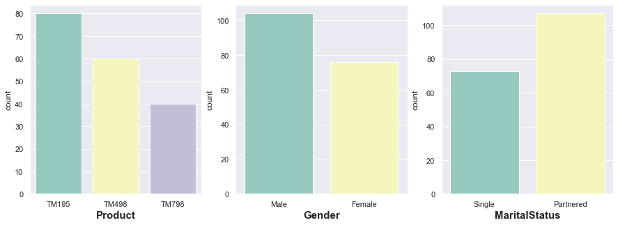

```python
# Below code shows visualizing the frequency distribution of categorical data
feature = ['Product','Gender','MaritalStatus']
list(enumerate(feature))
plt.figure(figsize=(15,5))
for i in enumerate(feature):
    plt.subplot(1,3,i[0]+1)
    plot = sns.countplot(i[1], data=cardiofit,palette='Set3')
    plot.set_xlabel(i[1],fontsize=15,fontweight='bold')
```

### Let us understand the frequency distribution of important Numerical data like Age, Education, Income, Usage, Miles, Fitness using different plots

#### 1. Understanding the variation in the data distribution using distplot

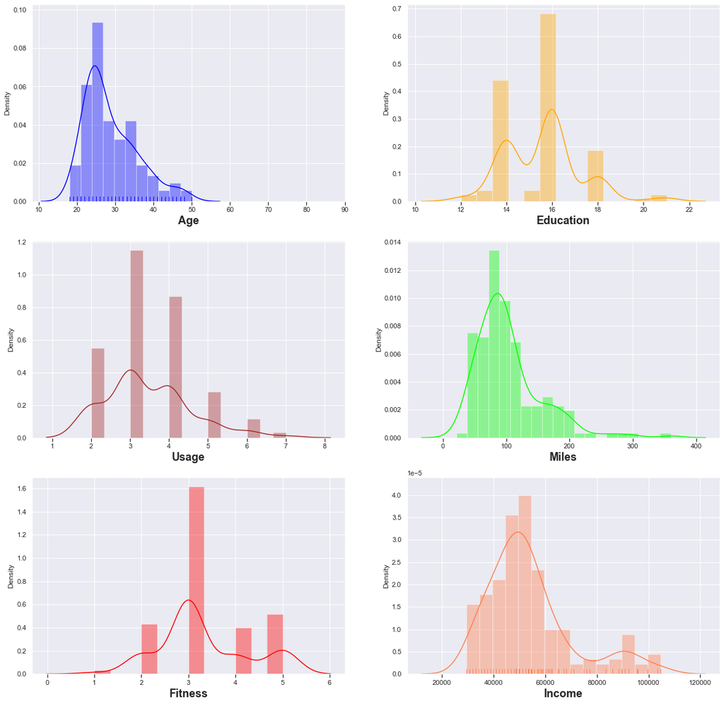

```python
# to visualize density distribution of numerical data using distplot of seaborn package
fig = plt.figure()
fig,ax = plt.subplots(3, 2,figsize=(20, 20)) # sub plots in 3 rows and 2 columns, so total 6 plots
# Below code will plot distribution of Age data
plot1 = sns.distplot(cardiofit.Age,color='blue',rug=True,ax=ax[0,0])
plot1.set_xlabel('Age',fontsize=18,fontweight='bold')
plot1.set_xticks(np.arange(10,100,10))
plot1.xaxis.set_ticks_position('bottom')
# Below code will plot distribution of Education data
plot2 = sns.distplot(cardiofit.Education,color='orange',ax=ax[0,1])
plot2.set_xlabel('Education',fontsize=18,fontweight='bold')
plot2.xaxis.set_ticks_position('bottom')
# Below code will plot distribution of Usage data
plot3 = sns.distplot(cardiofit.Usage,color='brown',ax=ax[1,0])
plot3.set_xlabel('Usage',fontsize=18,fontweight='bold')
plot3.xaxis.set_ticks_position('bottom')
# Below code will plot distribution of Miles data
plot4 = sns.distplot(cardiofit.Miles,color='lime',ax=ax[1,1])
plot4.set_xlabel('Miles',fontsize=18,fontweight='bold')
plot4.xaxis.set_ticks_position('bottom')
# Below code will plot distribution of Fitness data
plot5 = sns.distplot(cardiofit.Fitness,color='red',ax=ax[2,0])
plot5.set_xlabel('Fitness',fontsize=18,fontweight='bold')
plot5.xaxis.set_ticks_position('bottom')
# Below code will plot distribution of Income data
plot6 = sns.distplot(cardiofit.Income,color='coral',rug=True,ax=ax[2,1])
plot6.set_xlabel('Income',fontsize=18,fontweight='bold')
plot6.xaxis.set_ticks_position('bottom')
```

### Observations

- Both Age and Miles are right skewed where maximum number of customers buying Treadmill are in the age group 23 to 29 years old and expected to run less than 100 Miles. Lowest number of customers are of age > 40 years old.
- Large number of customers have around 15 years of education (so, most of the customers have been college with 3 years degree) and earn income around 52000 USD per annum .
- On an average, most customers use Treadmill 3 times per week
- The self rated Fitness level by most customers is 3.0 out of 5.0

### To visualize the data distribution based on 5 point summary: min,Q1(first Quartile),Median,Q3(third Quartile) and maximum.

### Also to know if data is symmetrical and if and how the data is skewed.

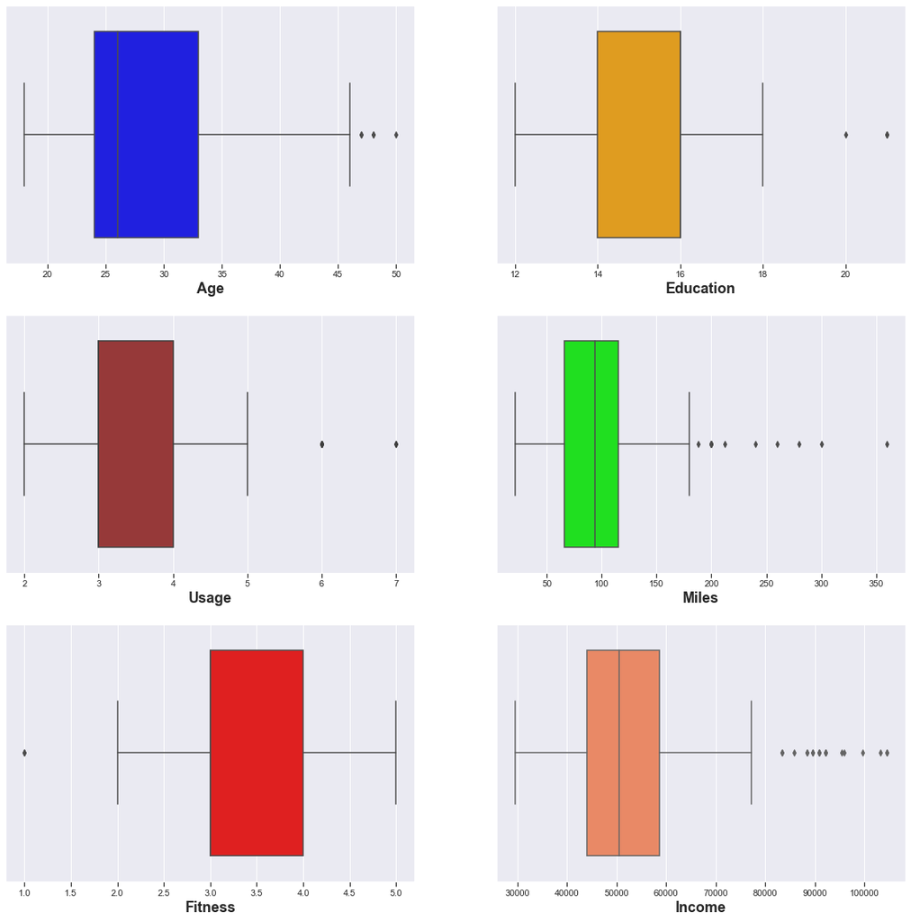

```python
# to visualize distribution of various important numerical data using boxplot of seaborn package
# From the box plots of the data, to obtain the 5 point summary insights
fig = plt.figure()
fig,ax = plt.subplots(3, 2,figsize=(20, 20)) # plot 6 subplots in 3 rows and 2 columns

# Below code to visualize boxplot of Age data
plot1 = sns.boxplot(cardiofit.Age,color='blue',ax=ax[0,0])
plot1.set_xlabel('Age',fontsize=18,fontweight='bold')
plot1.xaxis.set_ticks_position('bottom')

# Below code to visualize boxplot of Education data
plot2 = sns.boxplot(cardiofit.Education,color='orange',ax=ax[0,1])
plot2.set_xlabel('Education',fontsize=18,fontweight='bold')
plot2.xaxis.set_ticks_position('bottom')

# Below code to visualize boxplot of Usage data
plot3 = sns.boxplot(cardiofit.Usage,color='brown',ax=ax[1,0])
plot3.set_xlabel('Usage',fontsize=18,fontweight='bold')
plot3.xaxis.set_ticks_position('bottom')

# Below code to visualize boxplot of Miles data
plot4 = sns.boxplot(cardiofit.Miles,color='lime',ax=ax[1,1])
plot4.set_xlabel('Miles',fontsize=18,fontweight='bold')
plot4.xaxis.set_ticks_position('bottom')

# Below code to visualize boxplot of Fitness data
plot5 = sns.boxplot(cardiofit.Fitness,color='red',ax=ax[2,0])
plot5.set_xlabel('Fitness',fontsize=18,fontweight='bold')
plot5.xaxis.set_ticks_position('bottom')

# Below code to visualize boxplot of Income data
plot6 = sns.boxplot(cardiofit.Income,color='coral',ax=ax[2,1])
plot6.set_xlabel('Income',fontsize=18,fontweight='bold')
plot6.xaxis.set_ticks_position('bottom')
```

### Observations

- Age, Miles and Income have right skewed/positive skewed distribution with outliers towards the higher end.
  - Median Age is 26 years old. So, most of the customers are younger in the age group 23 to 33 years old. There are few outliers with customers > 46 years old to max of 50 years old purchasing Treadmill.
  - Miles has few outliers with some of the customers expecting to run > 200 miles per week
  - The Median income is ~50000 USD per annum and most of the customers are in lower pay range < 60K USD per annum. There are few outliers with few customers earning > 80 K USD per annum
- Education, Usage and Fitness has symmetrical distribution of the data where median is in the middle.
  - Education has few outliers at the higher end with few customers > 20 years of education.
  - Usage has few outliers at the higher end with few customers expected to use Treadmill 6 to 7 times a week
  - Most of the customers self rated their fitness at 3. There is outlier at the lower end with self rated fitness as poor at 1 scale.

### Another way to visualize distribution of various numerical data using histogram plot with mean and median on the plots

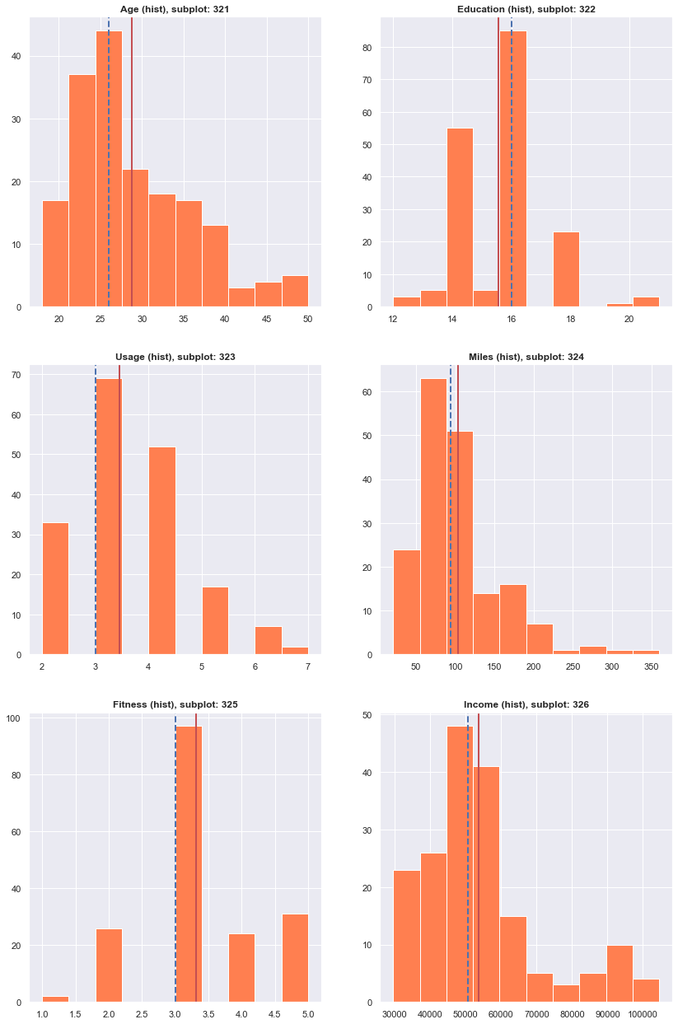

```python
# to visualize distribution of various important customer profile data (numerical data) using histogram plot of
# Matplotlib package and plot the mean and median on the plot
# mean = color code is red solid line
# median = color code is blue dotted line

cust_profile = ['Age', 'Education', 'Usage', 'Miles','Fitness','Income']
#list(enumerate(colors))
#  plot Numerical Data
a = 3  # number of rows
b = 2  # number of columns
c = 1  # initialize plot counter

fig = plt.figure(figsize=(14,22))
for i in cust_profile:
    plt.subplot(a, b, c)
    plt.title('{} (hist), subplot: {}{}{}'.format(i, a, b, c),fontsize=12,fontweight='bold')
    plt.hist(cardiofit[i],color='coral')
    plt.axvline(cardiofit[i].mean(), color='r', linewidth=2)
    plt.axvline(cardiofit[i].median(), color='b', linestyle='dashed', linewidth=2)
    c = c + 1
    continue

plt.show()
```

### Observations

- Mean customer age is 28 yeras old and Median is 26 years old. Most of the customers are < 35 years old. Customers drop > 35 years old.
- Income: Mean income is 52K USD per annum larger than median income 50K USD per annum. Most of the customers fall in first 4 bins, that is in lower pay range < 60K USD per annum
- Most of the customers expect to run 100 miles per week, mean and median is pretty close. Very few customers expect to run > 150 miles per week.
- There is not much variance of data with Education, Fitness and Usage
- Mean and Median self rated fitness scale is pretty close. Mean is 3.3 and Median is 3.0. Most of the customers fall in 3.0 bin
- Mean expected usage of Treadmill is 3.4 and Median expected usage of Treadmill is 3.0. Most of the customers fall in the 3 days per week bin
- Mean education is 16 years, close to the median. Most of the customers fall in the 16 years bin.

### Analyzing Relationships Between Numerical Variables

### 1. Create and Plot correlation Matrix of Customer Profile data

```python
cardiofit.corr() # creating a 2-D Matrix with correlation plots
```

|  | Age | Education | Usage | Fitness | Income | Miles |
| --- | --- | --- | --- | --- | --- | --- |
| Age | 1.00000 | 0.28050 | 0.01506 | 0.06110 | 0.51341 | 0.03662 |
| Education | 0.28050 | 1.00000 | 0.39516 | 0.41058 | 0.62583 | 0.30728 |
| Usage | 0.01506 | 0.39516 | 1.00000 | 0.66861 | 0.51954 | 0.75913 |
| Fitness | 0.06110 | 0.41058 | 0.66861 | 1.00000 | 0.53501 | 0.78570 |
| Income | 0.51341 | 0.62583 | 0.51954 | 0.53501 | 1.00000 | 0.54347 |
| Miles | 0.03662 | 0.30728 | 0.75913 | 0.78570 | 0.54347 | 1.00000 |

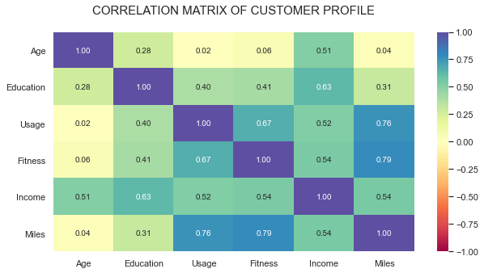

```python
plt.figure(figsize=(10, 5))
sns.heatmap(cardiofit.corr(), annot=True, vmin=-1, vmax=1, fmt=".2f", cmap="Spectral")
title = 'CORRELATION MATRIX OF CUSTOMER PROFILE\n'
plt.title(title, loc='center', fontsize=15)
plt.show()
```

### Observations

- Fitness has high positive correlation with average number of Miles the customer wants to run each week. This is expected.
- Usage has high positive correlation with Miles which is again expected. More number of miles the customer wants to run, the higher usage of the product will be every week.
- Fitness, Miles and Usage have high positive correlation with each other and are interdependant. As expected, all these values are highly correlated with each other.
- Education has high positive correlation with Income. As expected, higher the education of the customer, higher is the income.
- Fitness has fairly high positive correlation with Income. This shows that customers with better income self rated their fitness scale higher.
- Age has least correlation with Usage
- Fitness has least correlation with Age

### The same above heatmap correlation can be visualized using pair plot

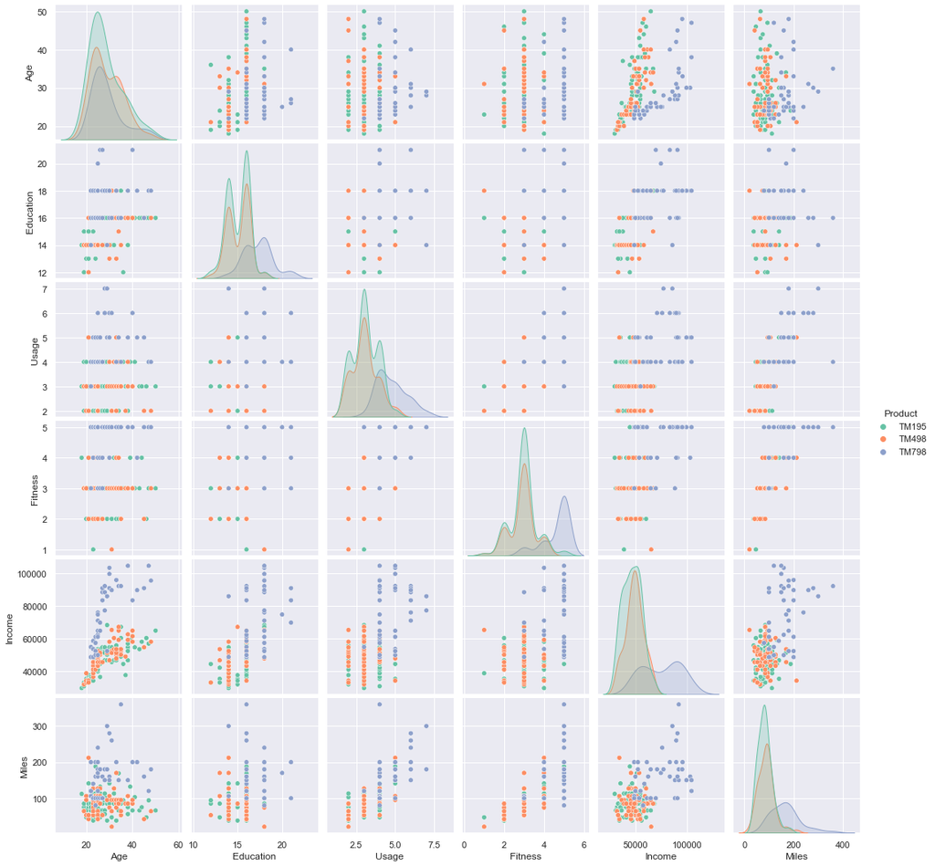

```python
sns.pairplot(cardiofit,hue='Product',palette="Set2", diag_kind="kde", height=2.5)
```

### 2. To identify the relationship between Product Vs Gender and Product Vs Marital Status

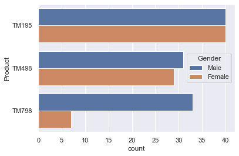

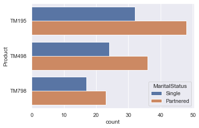

| MaritalStatus Gender Product | Partnered Female | Partnered Male | Single Female | Single Male |
| --- | --- | --- | --- | --- |
| TM195 | 27 | 21 | 13 | 19 |
| TM498 | 15 | 21 | 14 | 10 |
| TM798 | 4 | 19 | 3 | 14 |

```python
# Using count plot to identify Product Vs gender relationship
sns.countplot(y='Product',hue='Gender',data=cardiofit)
plt.show()
sns.countplot(y='Product',hue='MaritalStatus',data=cardiofit)
plt.show()
# To get tabular data with count of Male/Female & Single/Partnered customers for each Product
pd.crosstab(index=cardiofit["Product"],columns=[cardiofit["MaritalStatus"],cardiofit["Gender"]])
```

### Observations

- All 3 Treadmill models have more Partnered customers than Single customers
- TM195 Treadmill model has equal number of Male and Female customers (Male count=40, Female count=40)
- TM498 Treadmill model has almost equal number of Male and Female customers (Male count=31, Female count=29)
- TM798 Treadmill model has more Male customers (count = 33)
- TM798 Treadmill model has least Female customers (count = 7) compared to all other models. To investigate why ?

### 3. Visualize stacked bar plot to identify the relationship of customer profile:Miles,Education,Age, across each Product, Gender and Marital status

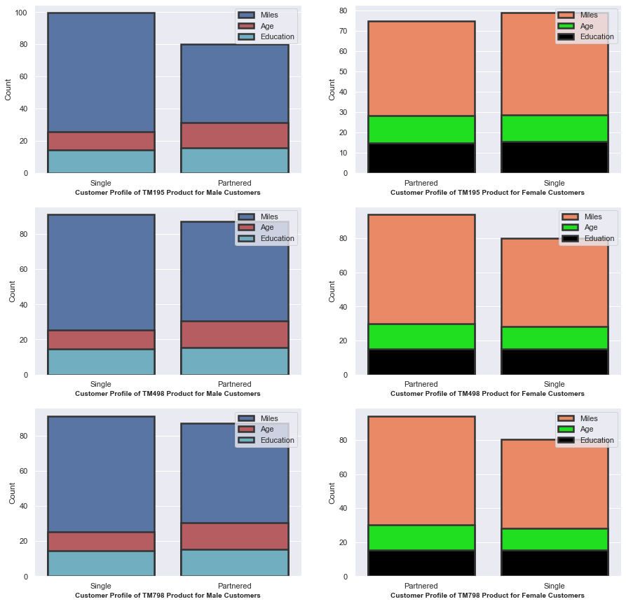

```python
# Grouping the date for each Product: TM195, TM498 and TM798 and for each Gender
product_group = cardiofit.groupby(['Product'])

TM195product_gender_group = product_group.get_group('TM195').groupby(['Gender'])
TM195_Male_data = TM195product_gender_group.get_group('Male')
TM195_Female_data = TM195product_gender_group.get_group('Female')

TM498product_gender_group = product_group.get_group('TM498').groupby(['Gender'])
TM498_Male_data = TM498product_gender_group.get_group('Male')
TM498_Female_data = TM498product_gender_group.get_group('Female')

TM798product_gender_group = product_group.get_group('TM498').groupby(['Gender'])
TM798_Male_data = TM798product_gender_group.get_group('Male')
TM798_Female_data = TM798product_gender_group.get_group('Female')

# Plotting into 6 subplots
fig = plt.figure()
fig,ax = plt.subplots(3, 2,figsize=(15, 15)) # plot 6 subplots in 3 rows and 2 columns

# CP Plot of TM195 Product Purchased by Male customers
plot1 = sns.barplot(x='MaritalStatus', y='Miles',data=TM195_Male_data,color="b",label='Miles',ci=None,linewidth=2.5,
                 errcolor=".2", edgecolor=".2",ax=ax[0,0])
sns.barplot(x='MaritalStatus', y='Age',data=TM195_Male_data,color="r",label='Age',ci=None,linewidth=2.5,
                 errcolor=".2", edgecolor=".2",ax=ax[0,0])
sns.barplot(x='MaritalStatus', y='Education', data=TM195_Male_data,color="c",label='Education',ci=None,linewidth=2.5,
                 errcolor=".2", edgecolor=".2",ax=ax[0,0])
plot1.set_xlabel('Customer Profile of TM195 Product for Male Customers',fontsize=10,fontweight='bold')
plot1.set_ylabel("Count")

# CP Plot of TM195 Product Purchased by Female customers
plot2 = sns.barplot(x='MaritalStatus', y='Miles',data=TM195_Female_data,color="coral",label='Miles',ci=None,linewidth=2.5,
                 errcolor=".2", edgecolor=".2",ax=ax[0,1])
sns.barplot(x='MaritalStatus', y='Age',data=TM195_Female_data,color="lime",label='Age',ci=None,linewidth=2.5,
                 errcolor=".2", edgecolor=".2",ax=ax[0,1])
sns.barplot(x='MaritalStatus', y='Education', data=TM195_Female_data,color="black",label='Education',ci=None,linewidth=2.5,
                 errcolor=".2", edgecolor=".2",ax=ax[0,1])
plot2.set_xlabel('Customer Profile of TM195 Product for Female Customers',fontsize=10,fontweight='bold')
plot2.set_ylabel("Count")

# CP Plot of TM498 Product Purchased by Male customers
plot3 = sns.barplot(x='MaritalStatus', y='Miles',data=TM498_Male_data,color="b",label='Miles',ci=None,linewidth=2.5,
                 errcolor=".2", edgecolor=".2",ax=ax[1,0])
sns.barplot(x='MaritalStatus', y='Age',data=TM498_Male_data,color="r",label='Age',ci=None,linewidth=2.5,
                 errcolor=".2", edgecolor=".2",ax=ax[1,0])
sns.barplot(x='MaritalStatus', y='Education', data=TM498_Male_data,color="c",label='Education',ci=None,linewidth=2.5,
                 errcolor=".2", edgecolor=".2",ax=ax[1,0])
plot3.set_xlabel('Customer Profile of TM498 Product for Male Customers',fontsize=10,fontweight='bold')
plot3.set_ylabel("Count")

# CP Plot of TM498 Product Purchased by Female customers
plot4 = sns.barplot(x='MaritalStatus', y='Miles',data=TM498_Female_data,color="coral",label='Miles',ci=None,linewidth=2.5,
                 errcolor=".2", edgecolor=".2",ax=ax[1,1])
sns.barplot(x='MaritalStatus', y='Age',data=TM498_Female_data,color="lime",label='Age',ci=None,linewidth=2.5,
                 errcolor=".2", edgecolor=".2",ax=ax[1,1])
sns.barplot(x='MaritalStatus', y='Education', data=TM498_Female_data,color="black",label='Eduation',ci=None,linewidth=2.5,
                 errcolor=".2", edgecolor=".2",ax=ax[1,1])
plot4.set_xlabel('Customer Profile of TM498 Product for Female Customers',fontsize=10,fontweight='bold')
plot4.set_ylabel("Count")

# CP Plot of TM798 Product Purchased by Male customers
plot5 = sns.barplot(x='MaritalStatus', y='Miles',data=TM798_Male_data,color="b",label='Miles',ci=None,linewidth=2.5,
                 errcolor=".2", edgecolor=".2",ax=ax[2,0])
sns.barplot(x='MaritalStatus', y='Age',data=TM798_Male_data,color="r",label='Age',ci=None,linewidth=2.5,
                 errcolor=".2", edgecolor=".2",ax=ax[2,0])
sns.barplot(x='MaritalStatus', y='Education', data=TM798_Male_data,color="c",label='Education',ci=None,linewidth=2.5,
                 errcolor=".2", edgecolor=".2",ax=ax[2,0])
plot5.set_xlabel('Customer Profile of TM798 Product for Male Customers',fontsize=10,fontweight='bold')
plot5.set_ylabel("Count")

# CP Plot of TM798 Product Purchased by Female customers
plot6 = sns.barplot(x='MaritalStatus', y='Miles',data=TM798_Female_data,color="coral",label='Miles',ci=None,linewidth=2.5,
                 errcolor=".2", edgecolor=".2",ax=ax[2,1])
sns.barplot(x='MaritalStatus', y='Age',data=TM798_Female_data,color="lime",label='Age',ci=None,linewidth=2.5,
                 errcolor=".2", edgecolor=".2",ax=ax[2,1])
sns.barplot(x='MaritalStatus', y='Education', data=TM798_Female_data,color="black",label='Education',ci=None,linewidth=2.5,
                 errcolor=".2", edgecolor=".2",ax=ax[2,1])
plot6.set_xlabel('Customer Profile of TM798 Product for Female Customers',fontsize=10,fontweight='bold')
plot6.set_ylabel("Count")

# Below code to customize the sub plots Y-label to 'count' and add legend
subplots = [0,1,2,3,4,5]
for i in range(len(subplots)):
    row=i//2
    col=i%2
    axes=ax[row,col]
    axes.legend(bbox_to_anchor=(1.0, 1.0), loc='upper right')

plt.show()
```

### 4. To visualize relationship between each Product and Customer Profile: Income,Usage,Fitness for each Gender/Marital Status customers

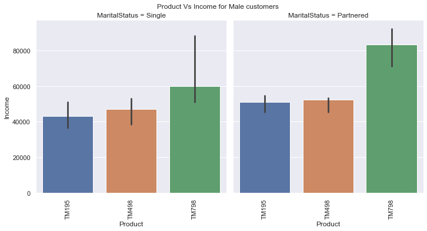

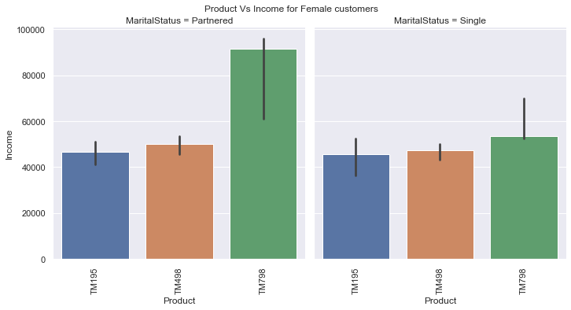

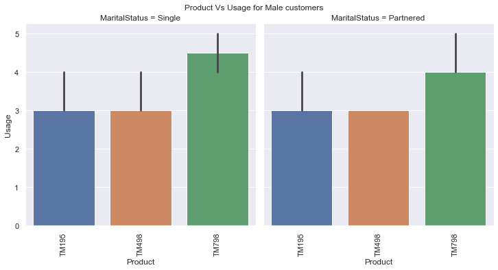

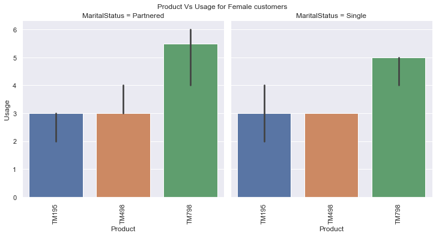

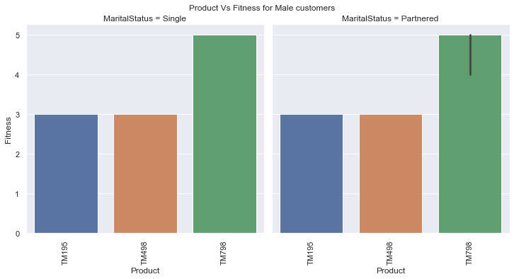

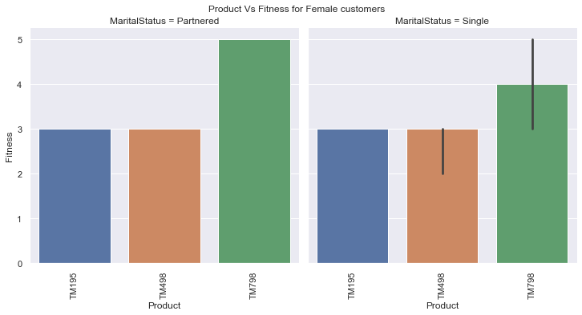

```python
# Using seaborn pckg catplot to plot
# To plot Product Vs Income for Male customers
cplot1=sns.catplot(x='Product', y='Income',
            data=cardiofit[cardiofit["Gender"].isin(["Male"])],
                estimator=np.median, col='MaritalStatus',kind="bar")
cplot1.set_xticklabels(rotation=90)
cplot1.fig.subplots_adjust(top=0.9) # adjust the Figure in cplot1
cplot1.fig.suptitle('Product Vs Income for Male customers')
plt.show()

# To plot Product Vs Income for Female customers
cplot2=sns.catplot(x='Product', y='Income',
            data=cardiofit[cardiofit["Gender"].isin(["Female"])],
                estimator=np.median, col='MaritalStatus',kind="bar")
cplot2.set_xticklabels(rotation=90)
cplot2.fig.subplots_adjust(top=0.9) # adjust the Figure in cplot2
cplot2.fig.suptitle('Product Vs Income for Female customers')
plt.show()

# To plot Product Vs Usage for Male customers
cplot3=sns.catplot(x='Product', y='Usage',
            data=cardiofit[cardiofit["Gender"].isin(["Male"])],
                estimator=np.median, col='MaritalStatus',kind="bar")
cplot3.set_xticklabels(rotation=90)
cplot3.fig.subplots_adjust(top=0.9) # adjust the Figure in cplot3
cplot3.fig.suptitle('Product Vs Usage for Male customers')
plt.show()

# To plot Product Vs Usage for Female customers
cplot4=sns.catplot(x='Product', y='Usage',
            data=cardiofit[cardiofit["Gender"].isin(["Female"])],
                estimator=np.median, col='MaritalStatus',kind="bar")
cplot4.set_xticklabels(rotation=90)
cplot4.fig.subplots_adjust(top=0.9) # adjust the Figure in cplot4
cplot4.fig.suptitle('Product Vs Usage for Female customers')
plt.show()

# To plot Product Vs Fitness for Male customers
cplot5=sns.catplot(x='Product', y='Fitness',
            data=cardiofit[cardiofit["Gender"].isin(["Male"])],
                estimator=np.median, col='MaritalStatus',kind="bar")
cplot5.set_xticklabels(rotation=90)
cplot5.fig.subplots_adjust(top=0.9) # adjust the Figure in cplot5
cplot5.fig.suptitle('Product Vs Fitness for Male customers')
plt.show()

# To plot Product Vs Fitness for Female customers
cplot6=sns.catplot(x='Product', y='Fitness',
            data=cardiofit[cardiofit["Gender"].isin(["Female"])],
                estimator=np.median, col='MaritalStatus',kind="bar")
cplot6.set_xticklabels(rotation=90)
cplot6.fig.subplots_adjust(top=0.9) # adjust the Figure in cplot6
cplot6.fig.suptitle('Product Vs Fitness for Female customers')
plt.show()
```

### Multivariate analysis for plotting conditional relationships between Gender and Marital Status for every Product and Customer profile

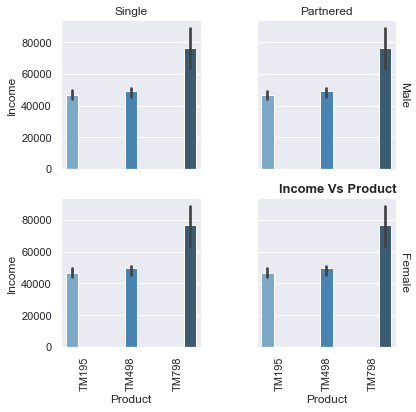

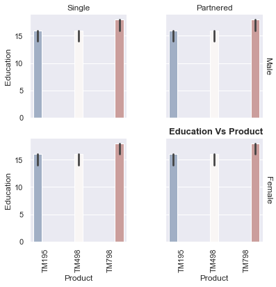

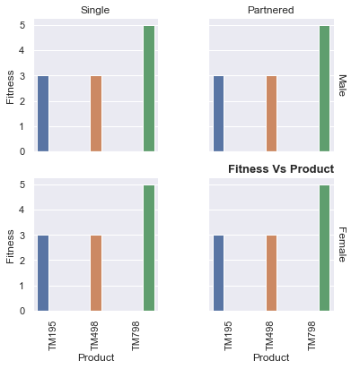

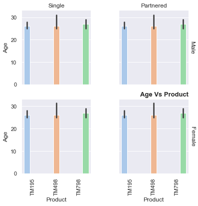

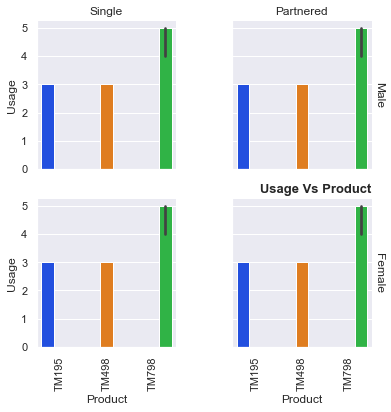

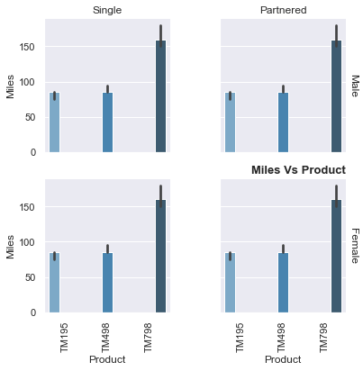

```python
# Create a facet grid with row = Gender and coloumn = Marital Status
g = sns.FacetGrid(cardiofit, col="MaritalStatus",  row="Gender",gridspec_kws={"wspace":0.4},margin_titles=True)

# bar plot of customer profile:Income against each Product
cplot1=g.map(sns.barplot, x='Product', y='Income',data=cardiofit,estimator=np.median, palette='Blues_d',hue='Product')
cplot1.set_xticklabels(rotation=90)
cplot1.set_titles(col_template="{col_name}", row_template="{row_name}")
cplot1.set_axis_labels("Product", "Income")
plt.title('Income Vs Product',fontsize=13,fontweight='bold',loc='right')
plt.show()
# bar plot of customer profile:Education against each Product
g = sns.FacetGrid(cardiofit, col="MaritalStatus",  row="Gender",gridspec_kws={"wspace":0.4},margin_titles=True)
cplot2=g.map(sns.barplot, x='Product', y='Education',data=cardiofit,estimator=np.median, palette='vlag',hue='Product')
cplot2.set_xticklabels(rotation=90)
cplot2.set_titles(col_template="{col_name}", row_template="{row_name}")
cplot2.set_axis_labels("Product", "Education")
plt.title('Education Vs Product',fontsize=13,fontweight='bold',loc='right')
plt.show()

# bar plot of customer profile:Fitness against each Product
g = sns.FacetGrid(cardiofit, col="MaritalStatus",  row="Gender",gridspec_kws={"wspace":0.4},margin_titles=True)
cplot3=g.map(sns.barplot, x='Product', y='Fitness',data=cardiofit,estimator=np.median, palette='deep',hue='Product')
cplot3.set_xticklabels(rotation=90)
cplot3.set_titles(col_template="{col_name}", row_template="{row_name}")
cplot3.set_axis_labels("Product", "Fitness")
plt.title('Fitness Vs Product',fontsize=13,fontweight='bold',loc='right')
plt.show()

# bar plot of customer profile:Age against each Product
g = sns.FacetGrid(cardiofit, col="MaritalStatus",  row="Gender",gridspec_kws={"wspace":0.4},margin_titles=True)
cplot3=g.map(sns.barplot, x='Product', y='Age',data=cardiofit,estimator=np.median, palette='pastel',hue='Product')
cplot3.set_xticklabels(rotation=90)
cplot3.set_titles(col_template="{col_name}", row_template="{row_name}")
cplot3.set_axis_labels("Product", "Age")
plt.title('Age Vs Product',fontsize=13,fontweight='bold',loc='right')
plt.show()

# bar plot of customer profile:Usage against each Product
g = sns.FacetGrid(cardiofit, col="MaritalStatus",  row="Gender",gridspec_kws={"wspace":0.4},margin_titles=True)
cplot3=g.map(sns.barplot, x='Product', y='Usage',data=cardiofit,estimator=np.median, palette='bright',hue='Product')
cplot3.set_xticklabels(rotation=90)
cplot3.set_titles(col_template="{col_name}", row_template="{row_name}")
cplot3.set_axis_labels("Product", "Usage")
plt.title('Usage Vs Product',fontsize=13,fontweight='bold',loc='right')
plt.show()

# bar plot of customer profile:Miles against each Product
g = sns.FacetGrid(cardiofit, col="MaritalStatus",  row="Gender",gridspec_kws={"wspace":0.4},margin_titles=True)
cplot3=g.map(sns.barplot, x='Product', y='Miles',data=cardiofit,estimator=np.median, palette='Blues_d',hue='Product')
cplot3.set_xticklabels(rotation=90)
cplot3.set_titles(col_template="{col_name}", row_template="{row_name}")
cplot3.set_axis_labels("Product", "Miles")
plt.title('Miles Vs Product',fontsize=13,fontweight='bold',loc='right')
plt.show()
```

### Observations

- Higher income customers ( > 70K USD per annum) purchased TM798 model
- Lower income customers (< 60 K per annum) purchased TM195 and TM498 models
- Higher Education customers ( 17 to 18 years of Education) puchased TM798 model. May be have advanced education after college
- Up to 16 years of Education customers purchased TM195 and TM498 models. May be with 4 years of college degree
- Higher self rated Fitness customers, up to scale 5, purchased TM798 model
- Average self rated Fitness, up to 3, purchased TM195 and TM498 models
- Higher age group customers, 26 to 33 years old, purchased TM498 model
- Age group of 26 to 29 years old customers purchased TM195 and TM798 models
- Customers with higher expected usage of Treadmill of up to 4 to 7 days a week purchased TM798 model
- Customers with average expected usage of Treadmill of up to 3 days a week purchased TM195 and TM498 models
- Customers with higher expected miles to run > 150 miles per week, purchased TM798 model
- Customers with average expected miles to run of up to 100 miles per week, purchased TM195 and TM498 models

### Customer Profile for Treadmill Model TM195

#### TM195 is the most purchased model, up to 80 sold.

- Average income is ~47K USD per annum, less than 60K USD per annum
- Average years of Education is 16 years. May be with 4 years of college degree
- Self rated fitness is 3.0 on an average
- Age ranging from 26 to 29 years old
- Average usage of Treadmill is 3 days per week
- Average number of miles expecting to run is 100 miles per week

### Customer Profile for Treadmill Model TM498

#### TM498 is the second most purchased model, up to 60 sold.

- Average income is ~47K USD per annum, less than 60K USD per annum
- Average years of Education is 16 years. May be with 4 years of college degree
- Self rated fitness is 3.0 on an average
- Age ranging from 26 to 33 years old
- Average usage of Treadmill is 3 days per week
- Average number of miles expecting to run is 100 miles per week

### Recommendations to increase sales

- TM798 model is the least sold model and more purchased by higher income customers than lower income customers. Assuming the reason to be cost here. Advertise this model with reduced price offer on special holidays to make it more affordable for lower income customers.
- Since the TM798 customers self rated thier fitness at higher scale, this might be one other reason for low sales of this product. Market additional features of the model to attract very fit customers like making it look more productive like spend less time to get more workout done.
- Market the 3 Treadmill models to attract more customers in the age group > 35 years old with benefits of being fit and healthy as you grow older
- To target more Female customers, market the Treadmill product online where the audience lives more online as per surveys. Use influencers to share the benefits of staying fit with women perspective.
- Since Partnered Female customers self rate their fitness higher and expect to run more miles, target more Partnered female customers by advertising with family perspective ads and include installment payments.
- Target customers with different advertsing stratergies like for male customers use more stats and for female customers use more emotions.
- Market TM195 and TM498 to higher income and higher education customers by advertising it with different startergies ads with vibrant colors like making it look more branded model highlighting special features and benefits.
- Single customers are less eventhough they expect to use more Treadmill and expect to run more. The reason may be because their self rated fitness is higher. Target more single customers by marketing the product on social media, start a friend referral program.